# no lpi models

Ohio bee data # Step 2: Urban Cleveland Pool to Local Greenspaces Comparing among Local habitats # CWM and Functional Diversity - Null Models GLMMs This time without LPI

```r
t <- read.csv("./btraits_final.csv", row.names=1)
a <- read.csv("./bcomm_final.localanalysis.csv", row.names=1)
str(a)
a1 <- a #save the original dataset

# pull out treatments that we want to keep
farm <- a[which(a$trmt == "Farm"),]
str(farm)
Control <- a[which(a$trmt == "Control"),]
str(Control)
T1 <- a[which(a$trmt == "T1"),]
str(T1)
T8 <- a[which(a$trmt == "T8"),]
str(T8)

# create new dataset with only farm, Control, t1, and t8 treatments
a <- rbind(farm, Control,T1, T8)
str(a)

a <- a[2:360]
str(a)
rowSums(a1[2:360])

# create a vector with the column sums for each species
# species not found in Cleveland will have a 0
sp <- colSums(a)
sp

# removes any columns (i.e. species) that are not found in Cleveland
a <- a[, colSums(a != 0) > 0]
colSums(a)

str(t)
names(t)
colnames(t) <- c("bl", "lec", "nest", "soc", "ori")
names(t)

# add the sp vector as a column in the trait matrix, shows which species
# are found in Cleveland and which are absent (i.e. with a 0)
t$sp <- sp
t

# uses the sp values to remove rows of species not collected in Cleveland
# then remove the column because we don't need it anymore
t <- t[t$sp != 0, ]
t <- t[,-6]

plot(t)
cor(t, method = c("pearson"), use = "complete.obs")
str(t)

t1 <- t #save the original dataset

t$lec <- as.factor(t$lec)
t$nest <- as.factor(t$nest)
t$soc <- as.factor(t$soc)

str(t) # have to keep origin as a integer for the trait distance matrix to work

#check body length for normality
hist(t$bl)
hist(log(t$bl))

t2 <- t #create another duplicate dataset before we transform
t2$bl <- log(t2$bl + 1)
str(t2)

#Double check that all species are present in both datasets
#Double check if a species is present in one dataset but not the other
setdiff(colnames(a), rownames(t2))
setdiff(rownames (t2), colnames(a))

rownames(t2) == colnames(a) # we are good to go
```

#Observed community metrics Loading needed packages

```r
if (!suppressWarnings(require(FD))) install.packages("FD")
citation("FD")

if (!suppressWarnings(require(picante))) install.packages("picante")
citation("picante")

if (!suppressWarnings(require(gawdis))) install.packages("gawdis")
citation("gawdis")

if (!suppressWarnings(require(betapart))) install.packages("betapart")
citation("betapart")
```

```r
rowSums(a)

#observed CWM
cwm.obs <- functcomp(t2, as.matrix(a), CWM.type = "all")
cwm.obs

#observed taxonomic beta diversity
# create beta part object for analyses
str(a)
b.core <- betapart.core(a)

# returns three dissimilarity matrices containing
# pairwise between-site values of each beta-diversity component
b.dist <- beta.pair(b.core, index.family = "sorensen")
str(b.dist)

#observed functional beta diversity
#create distance matrix with the traits
#optimized feature helps to weight the traits equally
tdis <- gawdis(t2, w.type = "optimized", opti.maxiter = 500)
attr(tdis, "correls")
attr(tdis, "weights")

# save trait weights for the null model
wt <- c(0.38, 0.18, 0.11, 0.12, 0.20)

#now run a principal coordinates analysis (PCoA) so we can collapse these traits into
#a few continuous axes for the functional diversity calculations
pcoB <- dudi.hillsmith(as.matrix(tdis), scannf = FALSE, nf = 4)
pcoB

# check correlations among axes and traits
cor(pcoB$li, t1, use = "complete.obs")

sum(pcoB$eig[1:4]) / sum(pcoB$eig)
sum(pcoB$eig[1:3]) / sum(pcoB$eig)
sum(pcoB$eig[1:2]) / sum(pcoB$eig)

t.ax <- as.matrix(pcoB$li[1:3])
b.fun <- functional.beta.pair(a, t.ax, index.family = "sorensen")
str(b.fun)
```

#Rao Function

```r
Rao<-function(sample, dfunc, dphyl, weight=F, Jost=F, structure=NULL)   {
  library(ade4)

####function Qdecomp by by VillÃger & Mouillot (J Ecol, 2008) modify by Wilfried Thuiller #####

Qdecomp = function(functdist,abundances, w=TRUE) {

# number and names of local communities
c<-dim(abundances)[1] ; namescomm<-row.names(abundances)
abundances<-as.matrix(abundances)

# if necessary, transformation of functdist into matrix object
if (is.matrix(functdist)==F) functdist<-as.matrix(functdist)

# checking 'abundances' and 'functdist' dimensions
if (dim(functdist)[1]!=dim(functdist)[2])  stop("error : 'functdist' has different number of rows and columns")
if (dim(abundances)[2]!=dim(functdist)[1]) stop("error : different number of species in 'functdist' and 'abundances' ")

# checking NA absence in 'functdist'
if (length(which(is.na(functdist)==T))!=0)  stop("error : NA in 'functdist'")

# replacement of NA by 0 in abundances
if (is.na(sum(abundances))==T)  {
for (i in 1:dim(abundances)[1])
for (j in 1:dim(abundances)[2] )
{ if(is.na(abundances[i,j])==T) abundances[i,j]<- 0 } # end of i j
} # end of if

#  species richness and total abundances in local communities
abloc<-apply(abundances,1,sum)
nbsploc<-apply(abundances,1,function(x) {length(which(x>0))} )

# relative abundances inside each local community
locabrel<-abundances/abloc

# alpha diversity
Qalpha=apply(locabrel, 1, function(x) t(x) %*%  functdist %*% x)

#Wc
Wc = abloc/sum(abloc)

# abundance-weighted mean alpha
mQalpha<-as.numeric(Qalpha%*%abloc/sum(abloc) )

#Villeger's correction
if(w==T) {
    # abundance-weighted mean alpha
    mQalpha<-as.numeric(Qalpha%*%abloc/sum(abloc) )
    totabrel<-apply(abundances,2,sum)/sum(abundances)
    Qalpha = Qalpha*Wc
}

# Rao's original definition: mean of Pi
else {
    mQalpha<-mean(Qalpha)
    totabrel<-apply(locabrel,2,mean)
    }


# gamma diversity
Qgamma<-( totabrel %*% functdist %*% totabrel ) [1]

# beta diversity
Qbeta<-as.numeric( Qgamma-mQalpha )

# standardized beta diversity
Qbetastd<-as.numeric(Qbeta/Qgamma )

# list of results
resQ<-list(Richness_per_plot=nbsploc, Relative_abundance= locabrel, Pi=totabrel, Wc=Wc, Species_abundance_per_plot=abloc, Alpha=Qalpha, Mean_alpha=mQalpha, Gamma=Qgamma, Beta=Qbeta, Standardize_Beta =Qbetastd )

return(resQ)

}


###########function disc originally from S. Pavoine####

disc = function (samples, dis = NULL, structures = NULL, Jost = F)
{
    if (!inherits(samples, "data.frame"))
        stop("Non convenient samples")
    if (any(samples < 0))
        stop("Negative value in samples")
    if (any(apply(samples, 2, sum) < 1e-16))
        stop("Empty samples")
    if (!is.null(dis)) {
        if (!inherits(dis, "dist"))
            stop("Object of class 'dist' expected for distance")
       # if (!is.euclid(dis))
            #stop("Euclidean property is expected for distance")
        dis <- as.matrix(dis)
        if (nrow(samples) != nrow(dis))
            stop("Non convenient samples")
    }
   if (!is.null(structures)) {
        if (!inherits(structures, "data.frame"))
            stop("Non convenient structures")
        m <- match(apply(structures, 2, function(x) length(x)),
            ncol(samples), 0)
        if (length(m[m == 1]) != ncol(structures))
            stop("Non convenient structures")
        m <- match(tapply(1:ncol(structures), as.factor(1:ncol(structures)),
            function(x) is.factor(structures[, x])), TRUE, 0)
        if (length(m[m == 1]) != ncol(structures))
            stop("Non convenient structures")
    }
    Structutil <- function(dp2, Np, unit, Jost) {
        if (!is.null(unit)) {
            modunit <- model.matrix(~-1 + unit)
            sumcol <- apply(Np, 2, sum)
            Ng <- modunit * sumcol
            lesnoms <- levels(unit)
        }
        else {
            Ng <- as.matrix(Np)
            lesnoms <- colnames(Np)
        }
        sumcol <- apply(Ng, 2, sum)
        Lg <- t(t(Ng)/sumcol)
        colnames(Lg) <- lesnoms
        Pg <- as.matrix(apply(Ng, 2, sum)/nbhaplotypes)
        rownames(Pg) <- lesnoms
        deltag <- as.matrix(apply(Lg, 2, function(x) t(x) %*%
            dp2 %*% x))
        ug <- matrix(1, ncol(Lg), 1)
        if(Jost) {
            #dp2 <- as.matrix(as.dist(dfunct01))
            deltag <- as.matrix(apply(Lg, 2, function(x) t(x) %*% dp2 %*% x))
            X=t(Lg) %*% dp2 %*% Lg
            alpha=1/2 * (deltag %*% t(ug) + ug %*% t(deltag))
            Gam = (X + alpha)/2
            alpha = 1/(1-alpha) #Jost correction
            Gam = 1/(1-Gam)  #Jost correction
            Beta_add = Gam - alpha
            Beta_mult = 100*(Gam - alpha)/Gam
        }
        else {
          deltag <- as.matrix(apply(Lg, 2, function(x) t(x) %*% dp2 %*% x))
          X=t(Lg) %*% dp2 %*% Lg
          alpha=1/2 * (deltag %*% t(ug) + ug %*% t(deltag))
          Gam = (X + alpha)/2
          Beta_add = Gam - alpha
          Beta_mult = 100*(Gam - alpha)/Gam
        }
        colnames(Beta_add) <- lesnoms
        rownames(Beta_add) <- lesnoms
        return(list(Beta_add = as.dist(Beta_add), Beta_mult = as.dist(Beta_mult),
          Gamma=as.dist(Gam), Alpha=as.dist(alpha), Ng = Ng, Pg = Pg))
    }
    Diss <- function(dis, nbhaplotypes, samples, structures, Jost) {
        structutil <- list(0)
        structutil[[1]] <- Structutil(dp2 = dis, Np = samples, NULL, Jost)
        diss <- list(structutil[[1]]$Alpha, structutil[[1]]$Gamma, structutil[[1]]$Beta_add, structutil[[1]]$Beta_mult)
         if (!is.null(structures)) {
            for (i in 1:length(structures)) {
                structutil[[i + 1]] <- Structutil(as.matrix(structutil[[1]]$Beta_add),
                  structutil[[1]]$Ng, structures[, i], Jost)
            }
            diss <- c(diss, tapply(1:length(structures), factor(1:length(structures)),
                function(x) as.dist(structutil[[x + 1]]$Beta_add)))
        }
        return(diss)
    }
    nbhaplotypes <- sum(samples)
    diss <- Diss(dis, nbhaplotypes, samples, structures, Jost)
    if (!is.null(structures)) {
        names(diss) <- c("Alpha", "Gamma", "Beta_add", "Beta_prop", "Beta_region")
        return(diss)
    }
    names(diss) <- c("Alpha", "Gamma", "Beta_add", "Beta_prop")
    return(diss)
}






  TD<-FD<-PD<-NULL

 #Taxonomic diversity
  dS <- matrix(1, nrow(sample), nrow(sample)) - diag(rep(1, nrow(sample)))
  temp_qdec<- Qdecomp(dS,t(sample), w=weight)   #Call the Qdecomp function for alpha, gamma and beta estimations.
  TD$Richness_per_plot = temp_qdec$Richness_per_plot
  TD$Relative_abundance = temp_qdec$Relative_abundance
  TD$Pi = temp_qdec$Pi
  TD$Wc = temp_qdec$Wc
  if(Jost){
    TD$Mean_Alpha = 1/(1-temp_qdec$Mean_alpha)
    TD$Alpha = 1/(1-temp_qdec$Alpha)
    TD$Gamma = 1/(1-temp_qdec$Gamma)
    TD$Beta_add = (TD$Gamma -TD$Mean_Alpha )
    TD$Beta_prop = 100*TD$Beta_add/TD$Gamma
    #Call the disc function for alpha, gamma and beta estimations for each pair of samples
    TD$Pairwise_samples<- disc(as.data.frame(sample), as.dist(dS), structure=structure, Jost=Jost)
    }
  else {
    TD$Mean_Alpha = temp_qdec$Mean_alpha
    TD$Alpha = temp_qdec$Alpha
    TD$Gamma = temp_qdec$Gamma
    TD$Beta_add = (TD$Gamma -TD$Mean_Alpha )
    TD$Beta_prop = 100*TD$Beta_add/TD$Gamma
    #Call the disc function for alpha, gamma and beta estimations for each pair of samples
    TD$Pairwise_samples <- disc(as.data.frame(sample), as.dist(dS), structure=structure, Jost=Jost)
  }

  #Functional diversity estimation
  if(!is.null(dfunc)){
    FD<-list()
    if(Jost){
      if(max(dfunc)>1) dfunc <- dfunc/max(dfunc)   #Make sure the distance are between 0 and 1 for the Jost correction
      temp_qdec<- Qdecomp(dfunc,t(sample), w=weight)   #Call the Qdecomp function for alpha, gamma and beta estimations.
       #  FD$Alpha = 1/(1-temp_qdec$Alpha)
         #  FD$Mean_Alpha = mean(FD$Alpha)
        FD$Mean_Alpha = 1/(1-temp_qdec$Mean_alpha)
      FD$Alpha = 1/(1-temp_qdec$Alpha)
      FD$Gamma = 1/(1-temp_qdec$Gamma)
      FD$Beta_add = (FD$Gamma -FD$Mean_Alpha )
      FD$Beta_prop = 100*FD$Beta_add/FD$Gamma
      #Call the disc function for alpha, gamma and beta estimations for each pair of samples
      FD$Pairwise_samples<- disc(as.data.frame(sample), as.dist(dfunc), structure=structure, Jost=Jost)
    }
    else {
      temp_qdec<- Qdecomp(dfunc,t(sample), w=weight) #Call the Qdecomp function for alpha, gamma and beta estimations.
      FD$Mean_Alpha = temp_qdec$Mean_alpha
      FD$Alpha = temp_qdec$Alpha
      FD$Gamma = temp_qdec$Gamma
      FD$Beta_add = (FD$Gamma -FD$Mean_Alpha )
      FD$Beta_prop = 100*FD$Beta_add/FD$Gamma
      #FD$Beta =  temp_qdec$Beta#
      #Call the disc function for alpha, gamma and beta estimations for each pair of samples
      FD$Pairwise_samples <- disc(as.data.frame(sample), as.dist(dfunc), structure=structure, Jost=Jost)
    }
  }
  #Phylogenetic diversity estimation
  if(!is.null(dphyl)){
    PD<-list()
    if(Jost){
      if(max(dphyl)>1) dphyl <- dphyl/max(dphyl)   #Make sure the distance are between 0 and 1 for the Jost correction
      temp_qdec<- Qdecomp(dphyl,t(sample), w=weight)   #Call the Qdecomp function for alpha, gamma and beta estimations.
      PD$Mean_Alpha = 1/(1-temp_qdec$Mean_alpha)
      PD$Alpha = 1/(1-temp_qdec$Alpha)
      PD$Gamma = 1/(1-temp_qdec$Gamma)
      PD$Beta_add = (PD$Gamma -PD$Mean_Alpha )
      PD$Beta_prop = 100*PD$Beta_add/PD$Gamma
      #Call the disc function for alpha, gamma and beta estimations for each pair of samples
      PD$Pairwise_samples<- disc(as.data.frame(sample), as.dist(dphyl), structure=structure, Jost=Jost)
    }
    else {
      temp_qdec<- Qdecomp(dphyl,t(sample), w=weight)  #Call the Qdecomp function for alpha, gamma and beta estimations.
      PD$Mean_Alpha = temp_qdec$Mean_alpha
      PD$Alpha = temp_qdec$Alpha
      PD$Gamma = temp_qdec$Gamma
      PD$Beta_add = (PD$Gamma -PD$Mean_Alpha )
      PD$Beta_prop = 100*PD$Beta_add/PD$Gamma
      #PD$Beta =  temp_qdec$Beta
      #Call the disc function for alpha, gamma and beta estimations for each pair of samples
      PD$Pairwise_samples <- disc(as.data.frame(sample), as.dist(dphyl), structure=structure, Jost=Jost)
    }




  }
  out <- list(TD, FD, PD)
  names(out) <- c("TD", "FD", "PD")
  return(out)

}
```

#observed functional alpha diversity

```r
#observed functional alpha diversity

#run the rao function first!
bb.rao <- Rao(sample = t(a), dfunc = tdis, dphyl = NULL, weight = FALSE, Jost = TRUE, structure = NULL)
falpha <- bb.rao$FD$Alpha
falpha
```

#run the null models with 999 iterations

```r
numberReps <- 999


#create matrices to store the results of each iteration of the null model, for each trait and index:
# for cwms
nbl <- nlec_0 <- nlec_1 <- nlec_2 <- nnest_1 <- nnest_2 <- nnest_3 <- nnest_4 <- nnest_5 <- nsoc_1 <- nsoc_2 <- nsoc_3 <- nsoc_4 <- nori_0 <- nori_1 <- matrix(NA,
                                                                                                                                                               nrow = nrow(a), ncol = numberReps, dimnames = list(rownames(a), paste0("n", 1:numberReps)))

# for taxonomic beta diversity
nbsim <- nbsne <- nbsor <- matrix(NA, nrow = nrow(a), ncol = numberReps,
                                  dimnames = list(rownames(a), paste0("n", 1:numberReps)))

# for functional beta diversity
nfalpha <- nfsim <- nfsne <- nfsor <- matrix(NA, nrow = nrow(a), ncol = numberReps,
                                  dimnames = list(rownames(a), paste0("n", 1:numberReps)))

#create null model for each repetition:

for(i in 1:numberReps){
  print(i)

  # randomized trait matrix
  ntraits <- t2[sample(1:nrow(t2)),]
  rownames(ntraits) <- rownames(t2)

  # randomized presence/absence matrix
  nsp <- randomizeMatrix(samp = a, null.model = "independentswap")

  # randomized trait distance matrix
  ntdis <- gawdis(ntraits, w.type = "user", W = wt)

  # CWM calculations
  cwm.null <- functcomp(x = ntraits, a = as.matrix(nsp), CWM.type = "all")
  nbl[,i] <- cwm.null$bl
  nlec_0[,i] <- cwm.null$lec_0
  nlec_1[,i] <- cwm.null$lec_1
  nlec_2[,i] <- cwm.null$lec_2
  nnest_1[,i] <- cwm.null$nest_1
  nnest_2[,i] <- cwm.null$nest_2
  nnest_3[,i] <- cwm.null$nest_3
  nnest_4[,i] <- cwm.null$nest_4
  nnest_5[,i] <- cwm.null$nest_5
  nsoc_1[,i] <- cwm.null$soc_1
  nsoc_2[,i] <- cwm.null$soc_2
  nsoc_3[,i] <- cwm.null$soc_3
  nsoc_4[,i] <- cwm.null$soc_4
  nori_0[,i] <- cwm.null$ori_0
  nori_1[,i] <- cwm.null$ori_1

  # Functional alpha diversity
  nrao <- Rao(sample = t(nsp), dfunc = ntdis, dphyl = NULL, weight = FALSE, Jost = TRUE, structure = NULL)
  nfalpha[,i] <- nrao$FD$Alpha

  # Taxonomic beta diversity indices
  nb.core <- betapart.core(nsp)
  nb.dist <- beta.pair(nb.core, index.family = "sorensen")
  nsim.dist <- as.matrix(nb.dist$beta.sim)
  nsne.dist <- as.matrix(nb.dist$beta.sne)
  nsor.dist <- as.matrix(nb.dist$beta.sor)
  nbsim[,i] <- colMeans(nsim.dist)
  nbsne[,i] <- colMeans(nsne.dist)
  nbsor[,i] <- colMeans(nsor.dist)

  # Functional beta diversity indices
  npco <- dudi.hillsmith(as.matrix(ntdis), scannf = FALSE, nf = 3)
  nt <- as.matrix(npco$li)
  nb.fun <- functional.beta.pair(nsp, nt, index.family = "sorensen")
  nfsim.dist <- as.matrix(nb.fun$funct.beta.sim)
  nfsne.dist <- as.matrix(nb.fun$funct.beta.sne)
  nfsor.dist <- as.matrix(nb.fun$funct.beta.sor)
  nfsim[,i] <- colMeans(nfsim.dist)
  nfsne[,i] <- colMeans(nfsne.dist)
  nfsor[,i] <- colMeans(nfsor.dist)

}

# save the output matrices
write.csv(nbl, file = "nbl.csv")
write.csv(nlec_0, file = "nlec_0.csv")
write.csv(nlec_1, file = "nlec_1.csv")
write.csv(nlec_2, file = "nlec_2.csv")
write.csv(nnest_1, file = "nnest_1.csv")
write.csv(nnest_2, file = "nnest_2.csv")
write.csv(nnest_3, file = "nnest_3.csv")
write.csv(nnest_4, file = "nnest_4.csv")
write.csv(nnest_5, file = "nnest_5.csv")
write.csv(nsoc_1, file = "nsoc_1.csv")
write.csv(nsoc_2, file = "nsoc_2.csv")
write.csv(nsoc_3, file = "nsoc_3.csv")
write.csv(nsoc_4, file = "nsoc_4.csv")
write.csv(nori_0, file = "nori_0.csv")
write.csv(nori_1, file = "nori_1.csv")

write.csv(nbsim, file = "tbeta_sim.csv")
write.csv(nbsne, file = "tbeta_sne.csv")
write.csv(nbsor, file = "tbeta_sor.csv")

write.csv(nfalpha, file = "falpha.csv")

write.csv(nfsim, file = "fbeta_sim.csv")
write.csv(nfsne, file = "fbeta_sne.csv")
write.csv(nfsor, file = "fbeta_sor.csv")
```

# load the output matrices

```r
nbl <- read.csv("Urban to Local_Null Models_HillSmith_3 Axes/nbl.csv", row.names=1)
nlec_0 <- read.csv("Urban to Local_Null Models_HillSmith_3 Axes/nlec_0.csv", row.names=1)
nlec_1 <- read.csv("Urban to Local_Null Models_HillSmith_3 Axes/nlec_1.csv", row.names=1)
nlec_2 <- read.csv("Urban to Local_Null Models_HillSmith_3 Axes/nlec_2.csv", row.names=1)
nnest_1 <- read.csv("Urban to Local_Null Models_HillSmith_3 Axes/nnest_1.csv", row.names=1)
nnest_2 <- read.csv("Urban to Local_Null Models_HillSmith_3 Axes/nnest_2.csv", row.names=1)
nnest_3 <- read.csv("Urban to Local_Null Models_HillSmith_3 Axes/nnest_3.csv", row.names=1)
nnest_4 <- read.csv("Urban to Local_Null Models_HillSmith_3 Axes/nnest_4.csv", row.names=1)
nnest_5 <- read.csv("Urban to Local_Null Models_HillSmith_3 Axes/nnest_5.csv", row.names=1)
nsoc_1 <- read.csv("Urban to Local_Null Models_HillSmith_3 Axes/nsoc_1.csv", row.names=1)
nsoc_2 <- read.csv("Urban to Local_Null Models_HillSmith_3 Axes/nsoc_2.csv", row.names=1)
nsoc_3 <- read.csv("Urban to Local_Null Models_HillSmith_3 Axes/nsoc_3.csv", row.names=1)
nsoc_4 <- read.csv("Urban to Local_Null Models_HillSmith_3 Axes/nsoc_4.csv", row.names=1)
nori_0 <- read.csv("Urban to Local_Null Models_HillSmith_3 Axes/nori_0.csv", row.names=1)
nori_1 <- read.csv("Urban to Local_Null Models_HillSmith_3 Axes/nori_1.csv", row.names=1)

nfalpha <- read.csv("Urban to Local_Null Models_HillSmith_3 Axes/falpha.csv", row.names=1)

nbsim <- read.csv("Urban to Local_Null Models_HillSmith_3 Axes/tbeta_sim.csv", row.names=1)
nbsne <- read.csv("Urban to Local_Null Models_HillSmith_3 Axes/tbeta_sne.csv", row.names=1)
nbsor <- read.csv("Urban to Local_Null Models_HillSmith_3 Axes/tbeta_sim.csv", row.names=1)

nfsim <- read.csv("Urban to Local_Null Models_HillSmith_3 Axes/fbeta_sim.csv", row.names=1)
nfsne <- read.csv("Urban to Local_Null Models_HillSmith_3 Axes/fbeta_sne.csv", row.names=1)
nfsor <- read.csv("Urban to Local_Null Models_HillSmith_3 Axes/fbeta_sor.csv", row.names=1)
```

# SES Calculations

```r
## body length
SES_bl <- (cwm.obs$bl - apply(nbl, MARGIN = 1, mean)) / apply(nbl, MARGIN = 1, sd, na.rm=T)
SES_bl

## lec_0 - Kleptoparasitic
SES_lec_0 <- (cwm.obs$lec_0 - apply(nlec_0, MARGIN = 1, mean)) / apply(nlec_0, MARGIN = 1, sd, na.rm=T)
SES_lec_0

## lec_1 - Generalist
SES_lec_1 <- (cwm.obs$lec_1 - apply(nlec_1, MARGIN = 1, mean)) / apply(nlec_1, MARGIN = 1, sd, na.rm=T)
SES_lec_1

## lec_2 - Specialist
SES_lec_2 <- (cwm.obs$lec_2 - apply(nlec_2, MARGIN = 1, mean)) / apply(nlec_2, MARGIN = 1, sd, na.rm=T)
SES_lec_2

## nest_1 - Soil
SES_nest_1 <- (cwm.obs$nest_1 - apply(nnest_1, MARGIN = 1, mean)) / apply(nnest_1, MARGIN = 1, sd, na.rm=T)
SES_nest_1

## nest_2 - Cavity
SES_nest_2 <- (cwm.obs$nest_2 - apply(nnest_2, MARGIN = 1, mean)) / apply(nnest_2, MARGIN = 1, sd, na.rm=T)
SES_nest_2

## nest_3 - Hive
SES_nest_3 <- (cwm.obs$nest_3 - apply(nnest_3, MARGIN = 1, mean)) / apply(nnest_3, MARGIN = 1, sd, na.rm=T)
SES_nest_3

## nest_4 - Pithy Stems
SES_nest_4 <- (cwm.obs$nest_4 - apply(nnest_4, MARGIN = 1, mean)) / apply(nnest_4, MARGIN = 1, sd, na.rm=T)
SES_nest_4

## nest_5 - Wood
SES_nest_5 <- (cwm.obs$nest_5 - apply(nnest_5, MARGIN = 1, mean)) / apply(nnest_5, MARGIN = 1, sd, na.rm=T)
SES_nest_5

## soc_1 - Subsocial
SES_soc_1 <- (cwm.obs$soc_1 - apply(nsoc_1, MARGIN = 1, mean)) / apply(nsoc_1, MARGIN = 1, sd, na.rm=T)
SES_soc_1

## soc_2 - Solitary
SES_soc_2 <- (cwm.obs$soc_2 - apply(nsoc_2, MARGIN = 1, mean)) / apply(nsoc_2, MARGIN = 1, sd, na.rm=T)
SES_soc_2

## soc_3 - Eusocial
SES_soc_3 <- (cwm.obs$soc_3 - apply(nsoc_3, MARGIN = 1, mean)) / apply(nsoc_3, MARGIN = 1, sd, na.rm=T)
SES_soc_3

## soc_4 - Parasitic
SES_soc_4 <- (cwm.obs$soc_4 - apply(nsoc_4, MARGIN = 1, mean)) / apply(nsoc_4, MARGIN = 1, sd, na.rm=T)
SES_soc_4

## ori_0 - Native
SES_ori_0 <- (cwm.obs$ori_0 - apply(nori_0, MARGIN = 1, mean)) / apply(nori_0, MARGIN = 1, sd, na.rm=T)
SES_ori_0

## ori_2 - Exotic
SES_ori_1 <- (cwm.obs$ori_1 - apply(nori_1, MARGIN = 1, mean)) / apply(nori_1, MARGIN = 1, sd, na.rm=T)
SES_ori_1

## taxonomic beta diversity----
beta.sor <- as.matrix(b.dist$beta.sor)
beta.sor <- colMeans(beta.sor)

beta.sim <- as.matrix(b.dist$beta.sim)
beta.sim <- colMeans(beta.sim)

beta.sne <- as.matrix(b.dist$beta.sne)
beta.sne <- colMeans(beta.sne)

beta.t <- data.frame(beta.sor, beta.sim, beta.sne)

## taxonomic diveristy - beta sor
SES_bsor <- (beta.t$beta.sor - apply(nbsor, MARGIN = 1, mean)) / apply(nbsor, MARGIN = 1, sd, na.rm=T)
SES_bsor

## taxonomic diveristy - beta sim
SES_bsim <- (beta.t$beta.sim - apply(nbsim, MARGIN = 1, mean)) / apply(nbsim, MARGIN = 1, sd, na.rm=T)
SES_bsim

## taxonomic diveristy - beta sne
SES_bsne <- (beta.t$beta.sne - apply(nbsne, MARGIN = 1, mean)) / apply(nbsne, MARGIN = 1, sd, na.rm=T)
SES_bsne

## functional diversity----
fbeta.sor <- as.matrix(b.fun$funct.beta.sor)
fbeta.sor <- colMeans(fbeta.sor)

fbeta.sim <- as.matrix(b.fun$funct.beta.sim)
fbeta.sim <- colMeans(fbeta.sim)

fbeta.sne <- as.matrix(b.fun$funct.beta.sne)
fbeta.sne <- colMeans(fbeta.sne)

beta.f <- data.frame(falpha, fbeta.sor, fbeta.sim, fbeta.sne)

## functional alpha  - Rao
SES_falpha <- (beta.f$falpha - apply(nfalpha, MARGIN = 1, mean)) / apply(nfalpha, MARGIN = 1, sd, na.rm=T)
SES_falpha

## functional diveristy - beta sor
SES_fbsor <- (beta.f$fbeta.sor - apply(nfsor, MARGIN = 1, mean)) / apply(nfsor, MARGIN = 1, sd, na.rm=T)
SES_fbsor

## functional diveristy - beta sim
SES_fbsim <- (beta.f$fbeta.sim - apply(nfsim, MARGIN = 1, mean)) / apply(nfsim, MARGIN = 1, sd, na.rm=T)
SES_fbsim

## functional diveristy - beta sne
SES_fbsne <- (beta.f$fbeta.sne - apply(nfsne, MARGIN = 1, mean)) / apply(nfsne, MARGIN = 1, sd, na.rm=T)
SES_fbsne

## combine all indices into one matrix
SES.all <- as.data.frame(cbind(SES_bl, SES_lec_0, SES_lec_1, SES_lec_2, SES_ori_0, SES_ori_1,
                           SES_nest_1, SES_nest_2, SES_nest_3, SES_nest_4, SES_nest_5,
                           SES_soc_1, SES_soc_2, SES_soc_3, SES_soc_4, SES_bsor, SES_bsim,
                           SES_bsne, SES_falpha, SES_fbsor, SES_fbsim, SES_fbsne))

write.csv(SES.all, file = "SES_Local.csv")
#import the SES data
SES.all <- read.csv("./SES_Local.csv", row.names = 1)
```

# import the landscape data

```r
land <- read.csv("./landscape.localanalysis.csv", row.names = 1)
str(land)

land$trmt <- as.factor(land$trmt)
str(land)

## merge landscape data with SES data
SES <- merge(SES.all, land, by = c("row.names"))
str(SES)

SES$site <- as.factor(SES$Row.names)
str(SES)

write.csv(SES, file = "SES.csv")
## pull out data for each treatment
farm <- SES[which(SES$trmt == "Farm"),]
str(farm)

control <- SES[which(SES$trmt == "Control"),]
str(control)

T1 <- SES[which(SES$trmt == "T1"),]
str(T1)

T8 <- SES[which(SES$trmt == "T8"),]
str(T8)
```

#Loading More packages

```r
if (!suppressWarnings(require(nortest))) install.packages("nortest")
citation("nortest")

if (!suppressWarnings(require(car))) install.packages("car")
citation("car")

if (!suppressWarnings(require(emmeans))) install.packages("emmeans")
citation("emmeans")

if (!suppressWarnings(require(bbmle))) install.packages("bbmle")
citation("bbmle")

if (!suppressWarnings(require(DHARMa))) install.packages("DHARMa")
citation("DHARMa")

if (!suppressWarnings(require(lme4))) install.packages("lme4")
citation("lme4")

if (!suppressWarnings(require(ggplot2))) install.packages("ggplot2")
citation("ggplot2")

if (!suppressWarnings(require(sjPlot))) install.packages("sjPlot")
citation("sjPlot")

if (!suppressWarnings(require(jtools))) install.packages("jtools")
citation("jtools")

if (!suppressWarnings(require(interactions))) install.packages("interactions")
citation("interactions")
```

```r
check relationships among landscape variables----
dotchart(land$pland, pch = 19)
dotchart(land$lpi, pch = 19)
dotchart(land$enn, pch = 19)
plot(land[2:4], pch = 19)
cor(land[2:4], method = c("pearson"), use = "complete.obs")
```

#Creating FS Matrix

```r
f.farm <- SES[which(SES$trmt == "Farm"),]
str(f.farm)

f.control <- SES[which(SES$trmt == "Control"),]
str(f.control)

FS_comps <- as.data.frame(rbind(f.control, f.farm))
```

#Creating KT Matrix

```r
k.t8 <- SES[which(SES$trmt == "T8"),]
str(k.t8)

k.t1 <- SES[which(SES$trmt == "T1"),]
str(k.t1)

KT_comps <- as.data.frame(rbind(k.t1, k.t8))#here you bind by rows rather than columns (like the code above)
```

#Creating VL Matrix

```r
VL_comps <- as.data.frame(rbind(f.control, k.t1))#here you bind by rows rather than columns (like the code above)
```

#Body Length Models Normality et al testing

```r
with(FS_comps, bartlett.test(SES_bl ~ trmt))
with(KT_comps, bartlett.test(SES_bl ~ trmt))
with(VL_comps, bartlett.test(SES_bl ~ trmt))
with(FS_comps, ad.test(SES_bl))
with(KT_comps, ad.test(SES_bl))
with(VL_comps, ad.test(SES_bl))
```

```r
#Full model
FS_bl.mod.full <- glm(SES_bl ~ trmt + pland + enn, family = gaussian, data = FS_comps)
summary(FS_bl.mod.full)
step(FS_bl.mod.full)
```

###Reduced model

```r
FS_bl.mod.red <- glm(SES_bl ~ pland + enn, family = gaussian, data = FS_comps)
summary(FS_bl.mod.red)
qqnorm(resid(FS_bl.mod.red))
qqline(resid(FS_bl.mod.red))
plot(simulateResiduals(FS_bl.mod.red))
densityPlot(rstudent(FS_bl.mod.red)) # check density estimate of the distribution of residuals
outlierTest(FS_bl.mod.red)
influenceIndexPlot(FS_bl.mod.red, vars = c("Cook"), id = list(n = 3))
```

```r
FS_bl.mod.null <- glm(SES_bl ~ 1, family = gaussian, data = FS_comps)

# model comparison techniques
anova(FS_bl.mod.full, FS_bl.mod.red, FS_bl.mod.null, test = "F")
AICctab(FS_bl.mod.full, FS_bl.mod.red, FS_bl.mod.null)
```

###Creating Graphs and Table data

```r
Anova(FS_bl.mod.red)

effect_plot(FS_bl.mod.red, pred = pland, interval = TRUE, partial.residuals = TRUE, x.label = '(PLAND)', y.label = 'Standardized Effect Sizes (SES)')
effect_plot(FS_bl.mod.red, pred = enn, interval = TRUE, partial.residuals = TRUE, x.label = '(ENN)', y.label = 'Standardized Effect Sizes (SES)')
```

###Katie’s BL models

```r
KT_bl.mod.full <- glm(SES_bl ~ trmt + pland + enn, family = gaussian, data = KT_comps)
summary(KT_bl.mod.full)
step(KT_bl.mod.full)
```

```r
KT_bl.mod.null <- glm(SES_bl ~ 1, family = gaussian, data = KT_comps)
summary(KT_bl.mod.null)
qqnorm(resid(KT_bl.mod.null))
qqline(resid(KT_bl.mod.null))
plot(simulateResiduals(KT_bl.mod.null))
densityPlot(rstudent(KT_bl.mod.null)) # check density estimate of the distribution of residuals
outlierTest(KT_bl.mod.null)
influenceIndexPlot(KT_bl.mod.null, vars = c("Cook"), id = list(n = 3))

# model comparison techniques
anova(KT_bl.mod.full, KT_bl.mod.null, test = "F")
AICctab(KT_bl.mod.full, KT_bl.mod.null)
```

###VL BL Models

```r
VL_bl.mod.full <- glm(SES_bl ~ trmt + pland + enn, family = gaussian, data = VL_comps)
summary(VL_bl.mod.full)
step(VL_bl.mod.full)
```

```r
VL_bl.mod.null <- glm(SES_bl ~ 1, family = gaussian, data = VL_comps)
summary(VL_bl.mod.null)
qqnorm(resid(VL_bl.mod.null))
qqline(resid(VL_bl.mod.null))
plot(simulateResiduals(VL_bl.mod.null))
densityPlot(rstudent(VL_bl.mod.null)) # check density estimate of the distribution of residuals
outlierTest(VL_bl.mod.null)
influenceIndexPlot(VL_bl.mod.null, vars = c("Cook"), id = list(n = 3))

# model comparison techniques
anova(VL_bl.mod.full, VL_bl.mod.null, test = "F")
AICctab(VL_bl.mod.full, VL_bl.mod.null)
```

# lecty

##lec_0- Kleptoparasitic

Normality Tests

```r
dotchart(SES$SES_lec_0, group = SES$trmt, pch = 19)
with(FS_comps, bartlett.test(SES_lec_0 ~ trmt))
with(KT_comps, bartlett.test(SES_lec_0 ~ trmt))
with(VL_comps, bartlett.test(SES_lec_0 ~ trmt))
with(FS_comps, ad.test(SES_lec_0))
with(KT_comps, ad.test(SES_lec_0))
with(VL_comps, ad.test(SES_lec_0))
```

####Frances

```r
FS_lec_0.mod.full <- glm(SES_lec_0 ~ trmt + pland + enn, family = gaussian, data = FS_comps)
summary(FS_lec_0.mod.full)
step(FS_lec_0.mod.full)
```

```r
FS_lec_0.mod.null <- glm(SES_lec_0 ~ 1, family = gaussian, data = FS_comps)
summary(FS_lec_0.mod.null)
qqnorm(resid(FS_lec_0.mod.null))
qqline(resid(FS_lec_0.mod.null))
plot(simulateResiduals(FS_lec_0.mod.null))
densityPlot(rstudent(FS_lec_0.mod.null)) # check density estimate of the distribution of residuals
outlierTest(FS_lec_0.mod.null)
influenceIndexPlot(FS_lec_0.mod.null, vars = c("Cook"), id = list(n = 3))
#It looks like the first point might be a significant outlier
FS_lec_0.mod.null2 <- update(FS_lec_0.mod.null, subset = -c(1))
summary(FS_lec_0.mod.null2)
compareCoefs(FS_lec_0.mod.null, FS_lec_0.mod.null2) # compares estimated coefficients and their standard errors
#For some reason I got an error when I tried the above code
#And I can't test the below comparisons, because they don't run with it having 1 fewer data point

# model comparison techniques
anova(FS_lec_0.mod.full, FS_lec_0.mod.null,  test = "F")
AICctab(FS_lec_0.mod.full, FS_lec_0.mod.null)
```

####Katies

```r
KT_lec_0.mod.full <- glm(SES_lec_0 ~ trmt + pland + enn, family = gaussian, data = KT_comps)
summary(KT_lec_0.mod.full)
step(KT_lec_0.mod.full)
```

```r
KT_lec_0.mod.red <- glm(SES_lec_0 ~ enn, family = gaussian, data = KT_comps)
summary(KT_lec_0.mod.red)
```

```
Call:
glm(formula = SES_lec_0 ~ enn, family = gaussian, data = KT_comps)

Deviance Residuals:
     Min        1Q    Median        3Q
-0.89095  -0.17647  -0.02658   0.25475
     Max
 0.67545

Coefficients:
            Estimate Std. Error t value
(Intercept)  -0.7560     0.6938  -1.090
enn          -0.1539     0.1087  -1.415
            Pr(>|t|)
(Intercept)    0.294
enn            0.179

(Dispersion parameter for gaussian family taken to be 0.1793146)

    Null deviance: 2.8696  on 15  degrees of freedom
Residual deviance: 2.5104  on 14  degrees of freedom
AIC: 21.772

Number of Fisher Scoring iterations: 2
```

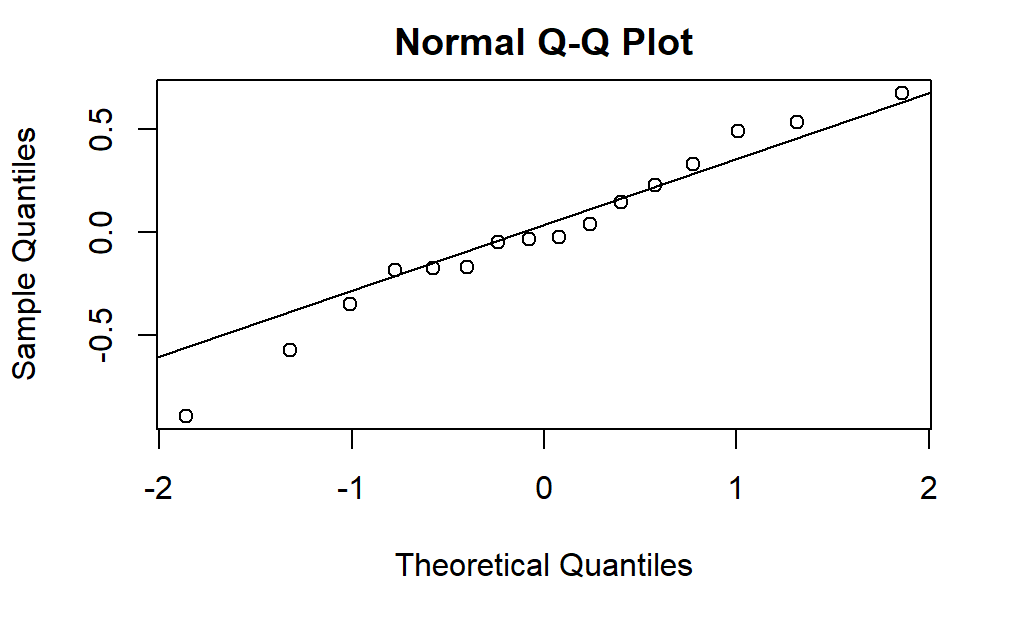

```r
qqnorm(resid(KT_lec_0.mod.red))
qqline(resid(KT_lec_0.mod.red))
```

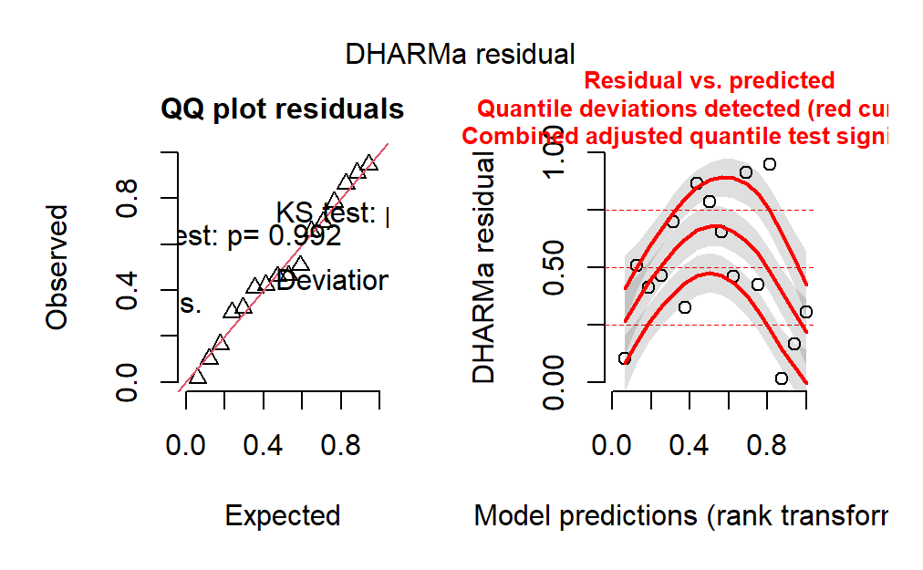

```r
plot(simulateResiduals(KT_lec_0.mod.red))
```

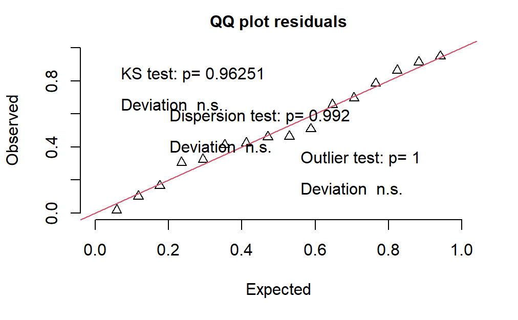

```r
#I am adding the below code to look at the graphs individually. the second one has red lines
plotQQunif(KT_lec_0.mod.red)
```